# NFL Punt Rule Change Win Probability Impact

This report examines the impact on a team’s win probability from our proposed rule changes to incentivize less returns on punts by NFL teams.

We first gather NFL.com play-by-play data accessed via the `nflscrapR` in `R`, with all pre-, post-, and regular season data for the 2016 and 2017 seasons available here: https://github.com/ryurko/nflscrapR-data/tree/master/play_by_play_data

```r
# Access tidyverse:
# install.packages("tidyverse")
library(tidyverse)
# Access nflscrapR:
# install_packages("devtools")
# devtools::install_github(repo = "maksimhorowitz/nflscrapR")
library(nflscrapR)
# Load the play-by-play data from the 2016 and 2017 season available in the repository above:
# Create the combination of year and type of games to access data for:
season_type_data <- expand.grid(c(2016, 2017),
                              c("pre", "regular", "post")) %>%
  rename(season = Var1, type = Var2)
# Join all of these seasons together:
pbp_data <- map2_dfr(season_type_data$season, as.character(season_type_data$type),
                    .f = function(season, type) {
                      # Shorten abbreviation to reg for regular season:
                      type_abbr <- if_else(type == "regular", "reg", type)

                      # Now load the data:
                      read_csv(paste0(
                        "https://raw.githubusercontent.com/ryurko/nflscrapR-data/master/play_by_play_data/",
                        type, "_season/", type_abbr, "_pbp_", season, ".csv"),
                        progress = FALSE)
                    })
# Access all punts as well as any play following the punt in order to have
# proper win probability calculation:
punt_pbp_data <- pbp_data %>%
  group_by(game_id) %>%
  # Create booleans for the certain situations we're interested in making
  # rule changes for:
  mutate(follow_punt = ifelse(lag(play_type == "punt"), TRUE, FALSE),
         follow_fair_catch = ifelse(lag(punt_fair_catch) == 1, TRUE, FALSE),
         follow_punt_oob = ifelse(lag(punt_out_of_bounds) == 1, TRUE, FALSE),
         follow_punt_touchback = ifelse(follow_punt & lag(touchback == 1),
                                        TRUE, FALSE),
         follow_downed_punt = ifelse(lag(punt_downed) == 1, TRUE, FALSE)) %>%
  filter(play_type == "punt" |
         follow_punt) %>%
  ungroup()
```

Since our proposed rule change to lower the concussion rate on punts is to simply incentivize teams to return less often, it is necessary to view the impact of our proposed incentives on the game itself. We propose the following two rule changes:

1. Return team gains 5 additional yards on a fair catch (**incentive for return team**).
2. Return team loses 5 yards from the point the ball goes out of bounds in the air (**incentive for the punting team**).

There are no proposed incentive structures for punts that land in play, regular rules will apply.

The histogram below displays the distribution of return yards for all punt returns (excluding fair catch, touchbacks, out of bounds, and downed punts) with a reference line at our proposed shift of five yards. Roughly 46.18% of punt returns are less than or equal to 5 yards.

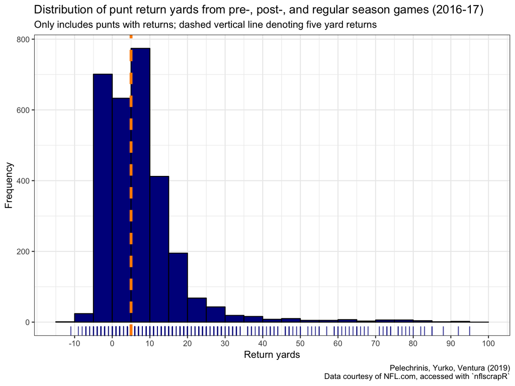

```r
punt_pbp_data %>%
  filter(play_type == "punt",
         punt_fair_catch == 0 & punt_out_of_bounds == 0 &
           touchback == 0 &
           punt_downed == 0) %>%
  ggplot(aes(x = return_yards)) +
  geom_histogram(fill = "darkblue", color = "black",
                 breaks = seq(-15, 100, by = 5)) +
  scale_x_continuous(limits = c(-15, 100), breaks = seq(-10, 100, by = 10)) +
  geom_rug(color = "darkblue", alpha = 0.75) +
  geom_vline(xintercept = 5, color = "darkorange", linetype = "dashed", size = 1.5) +
  labs(x = "Return yards",
       y = "Frequency",
       title = "Distribution of punt return yards from pre-, post-, and regular season games (2016-17)",
       subtitle = "Only includes punts with returns; dashed vertical line denoting five yard returns",
       caption = "Pelechrinis, Yurko, Ventura (2019)\nData courtesy of NFL.com, accessed with `nflscrapR`") +
  theme_bw()
```

The empirical CDF below is displaying the same information, but now is it easier to see that the proposed yardage shift of 5 yards is comparable to the median of return yards which is 6 yards.

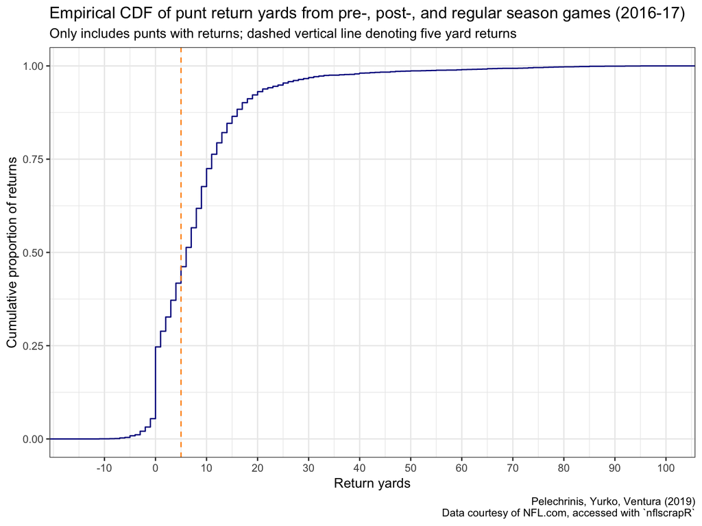

```r
punt_pbp_data %>%
  filter(play_type == "punt",
         punt_fair_catch == 0 & punt_out_of_bounds == 0 &
           touchback == 0 & punt_downed == 0) %>%
  ggplot(aes(x = return_yards)) +
  stat_ecdf(color = "darkblue") +
  scale_x_continuous(limits = c(-15, 100), breaks = seq(-10, 100, by = 10)) +
  geom_vline(xintercept = 5, color = "darkorange", linetype = "dashed") +
  labs(x = "Return yards",
       y = "Cumulative proportion of returns",
       title = "Empirical CDF of punt return yards from pre-, post-, and regular season games (2016-17)",
       subtitle = "Only includes punts with returns; dashed vertical line denoting five yard returns",
       caption = "Pelechrinis, Yurko, Ventura (2019)\nData courtesy of NFL.com, accessed with `nflscrapR`") +
  theme_bw()
```

Next, using the win probability in `nflscrapR` (Yurko, Ventura, and Horowitz 2018), we calculate the win probability added from the proposed change for all punt returns with a fair catch or out of bounds, and compare it to the win probability added from returns. This means we are comparing the change in win probability from where the returning team would have hypothetically received the ball given the current rules to where the return ends or the 5 yard shift from the proposed rule change. Downed punts and touchbacks are not included in the figure below.

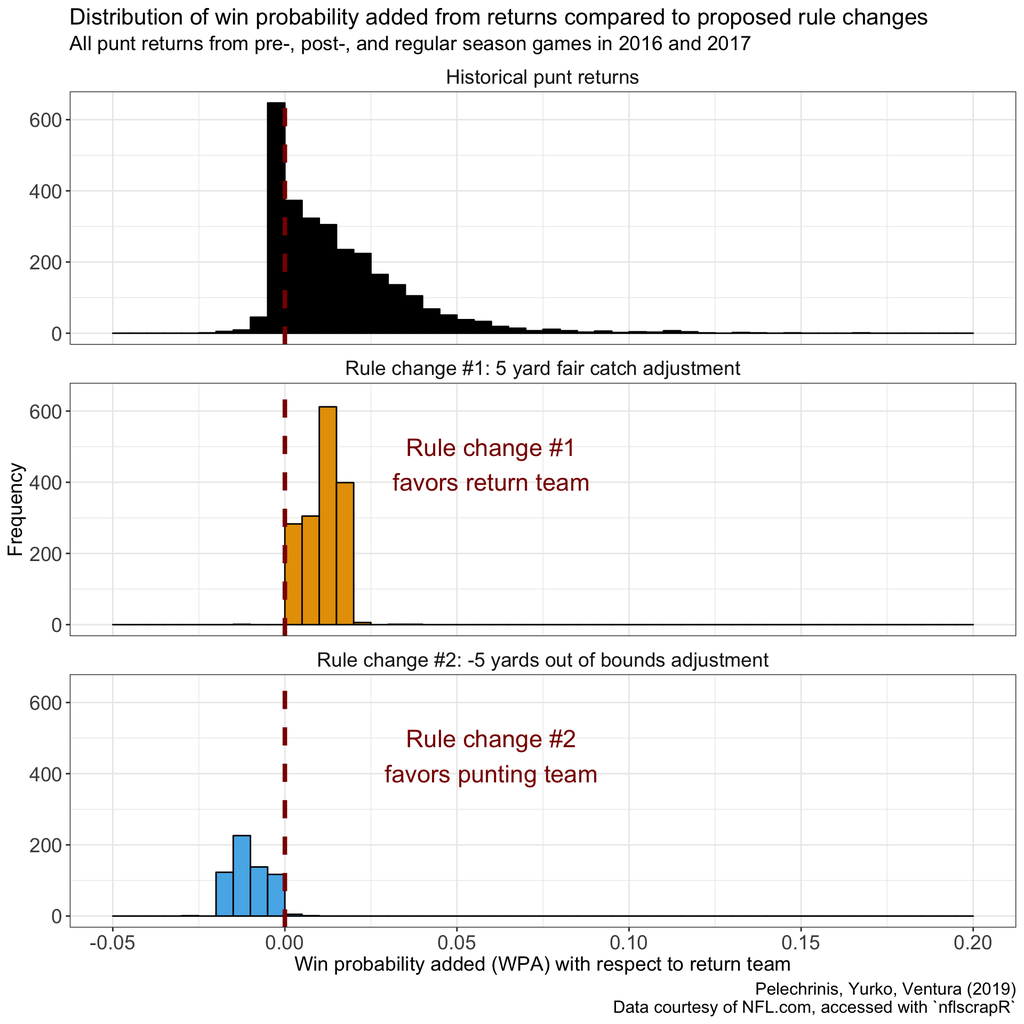

The figure below just displays the empirical CDF form of the above chart:

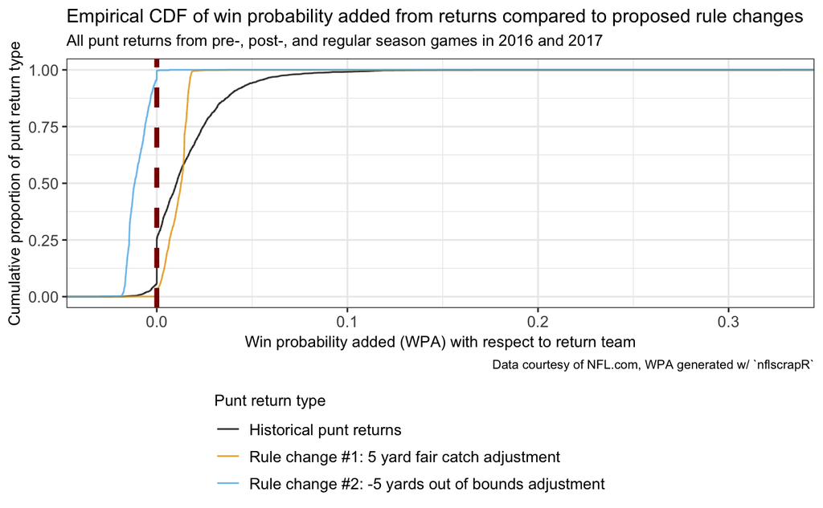

```r
ecdf_war_plot <- punt_adj_data %>%
  # Only look at the plays following punts, removing QB kneels and overtime:
  filter(follow_punt, play_type != "qb_kneel", qtr != 5) %>%
  # Reorder and relabel the punt_type:
  mutate(punt_type = fct_relevel(punt_type, "return", "fair_catch",
                                 "out_of_bounds"),
         punt_type = fct_recode(punt_type, `Historical punt returns` = "return",
                                              `Rule change #1: 5 yard fair catch adjustment` = "fair_catch",
                                              #`Rule change: touchback` = "touchback",
                                              `Rule change #2: -5 yards out of bounds adjustment` = "out_of_bounds")) %>%
  # Create beeswarm plots with boxplots overtop:
  ggplot(aes(x = rule_change_wpa, color = punt_type)) +
  stat_ecdf(alpha = 0.8) +
  ggthemes::scale_color_colorblind() +
  geom_vline(xintercept = 0, linetype = "dashed", color = "darkred", size = 1.5) +
  labs(title = "Empirical CDF of win probability added from returns compared to proposed rule changes",
       #subtitle = "Calculated with respect to possession team",
       subtitle = "All punt returns from pre-, post-, and regular season games in 2016 and 2017",
       caption = "Data courtesy of NFL.com, WPA generated w/ `nflscrapR`",
       x = "Win probability added (WPA) with respect to return team",
       y = "Cumulative proportion of punt return type",
       color = "Punt return type") +
  #scale_y_discrete(expand = c(0.01, 0.01)) +
  #scale_x_continuous(limits = c(-.5, .5)) +
  theme_bw() +
  theme(axis.title = element_text(size = 10),
        axis.text = element_text(size = 10),
        plot.title = element_text(size = 12),
        plot.subtitle = element_text(size = 10),
        plot.caption = element_text(size = 8),
        strip.background = element_blank(),
        strip.text = element_text(size = 14),
        legend.text = element_text(size = 10),
        legend.title = element_text(size = 10))
library(cowplot)
ecdf_legend <- get_legend(ecdf_war_plot)
plot_grid(ecdf_war_plot + theme(legend.position = "none"),
          ecdf_legend, ncol = 1, rel_heights = c(3,1))
```

# References

Yurko, Ronald, Samuel Ventura, and Maksim Horowitz. 2018. “nflWAR: A Reproducible Method for Offensive Player Evaluation in Football.” *arXiv E-Prints*, February.